# Edge Threshold Sensitivity Analysis

Robustness of network topological properties across pruning thresholds

Automated pipeline

2026-04-08

# 1. Overview

This report evaluates the sensitivity of global network topological properties to the number of edges retained during network pruning. Networks were pruned at thresholds of **10, 50, 100, 200, 300, 500** thousand edges (top-N by mutual information score). If the key findings reported in the manuscript are robust, the **relative ordering** of networks across metrics should remain stable across thresholds, even as absolute values change.

Networks and thresholds analysed

| region | phenotype | thresholds_tested |
| --- | --- | --- |
| CRB | AD | 6 |
| CRB | control | 6 |
| DLPFC | AD | 6 |
| DLPFC | control | 6 |
| HCN | AD | 6 |
| HCN | control | 6 |
| PCC | AD | 6 |
| PCC | control | 6 |
| TC | AD | 6 |
| TC | control | 6 |

# 2. Global metrics across thresholds

## 2.1 Number of nodes

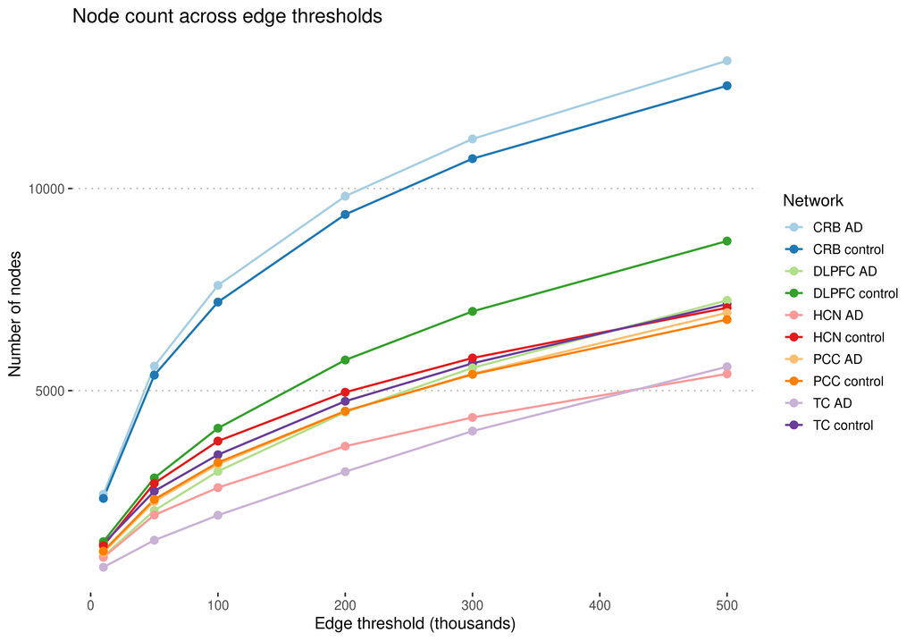

## 2.2 Network density

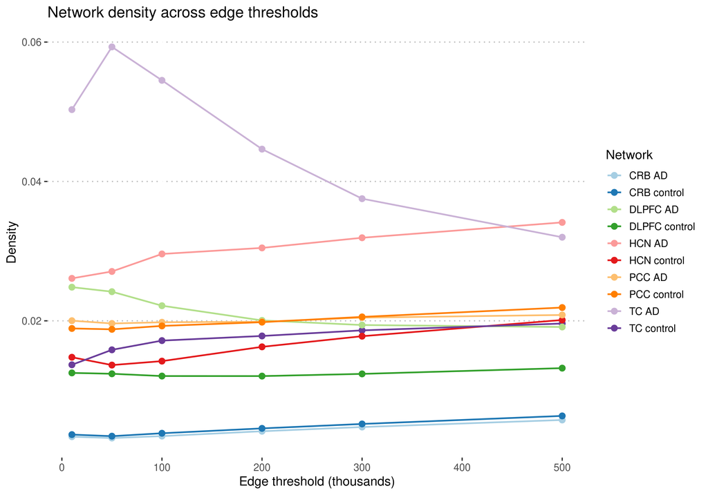

## 2.3 Mean degree

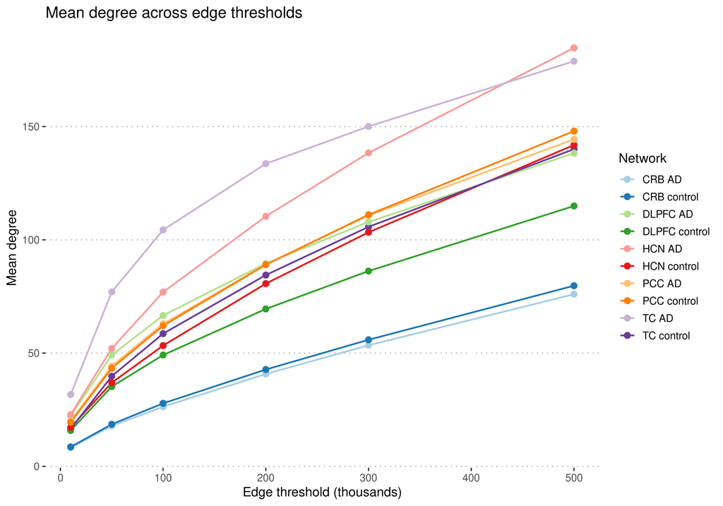

## 2.4 Giant component fraction

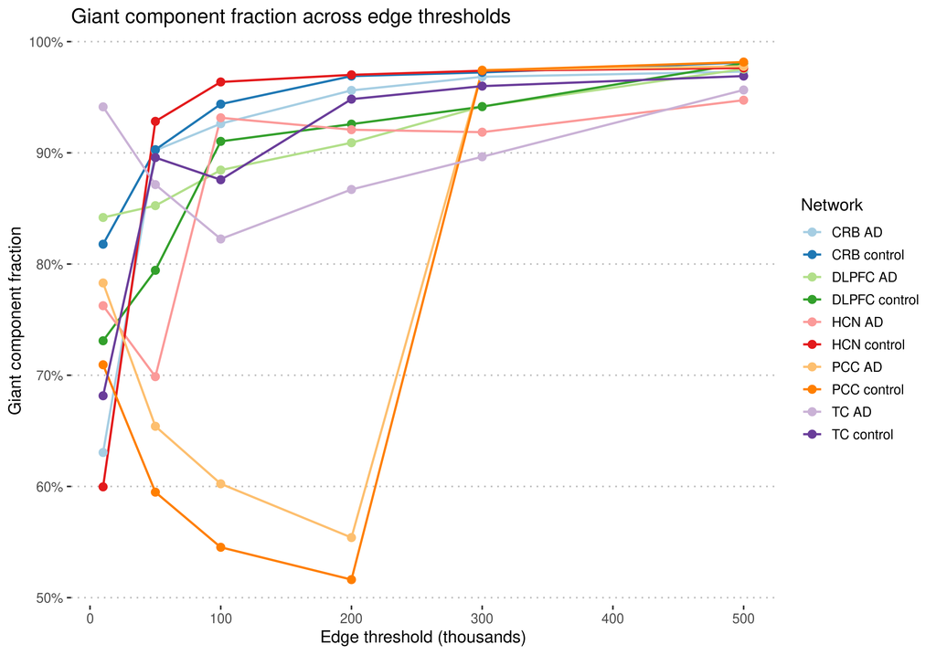

## 2.5 Average path length

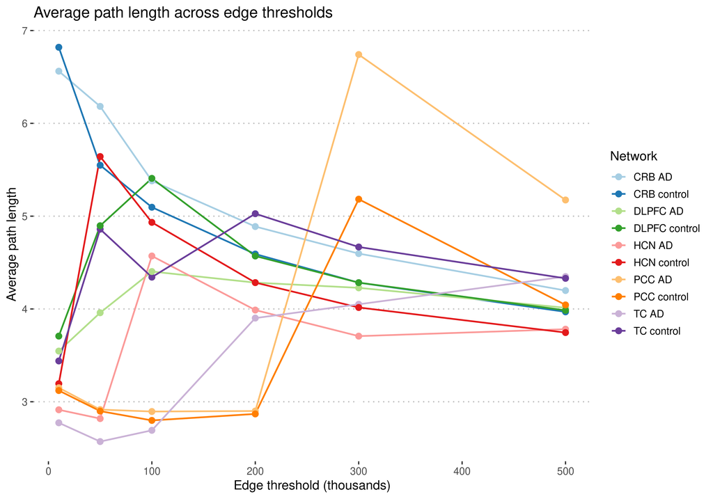

## 2.6 Diameter

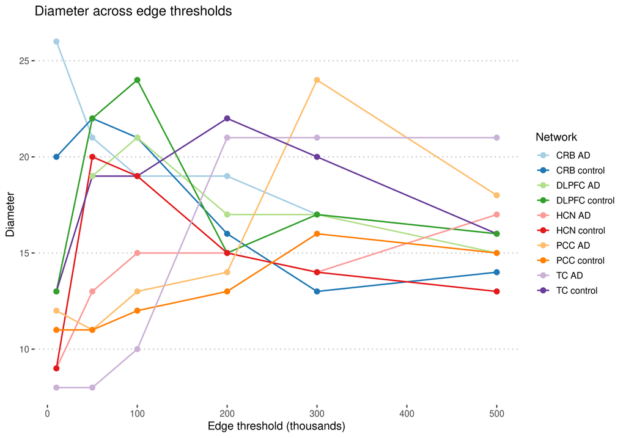

## 2.7 Clustering coefficient (global)

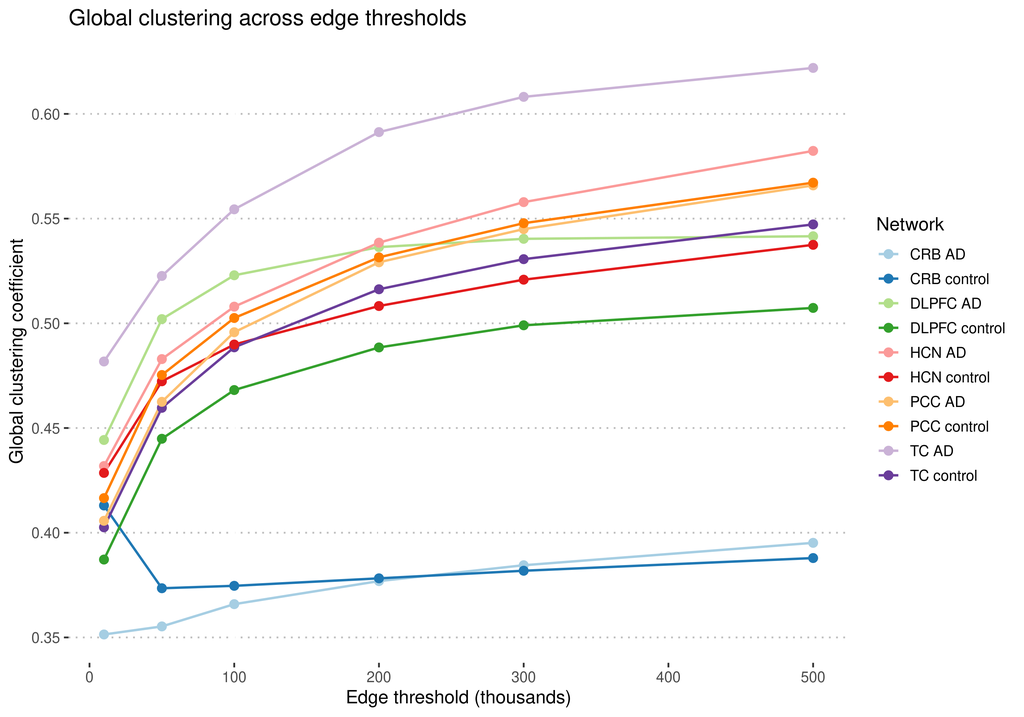

## 2.8 Modularity (Louvain Q)

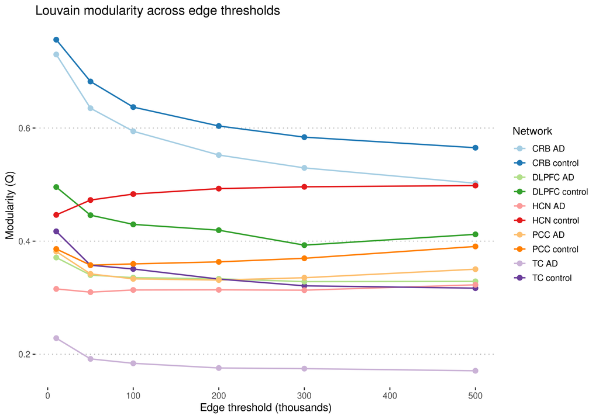

## 2.9 Number of communities

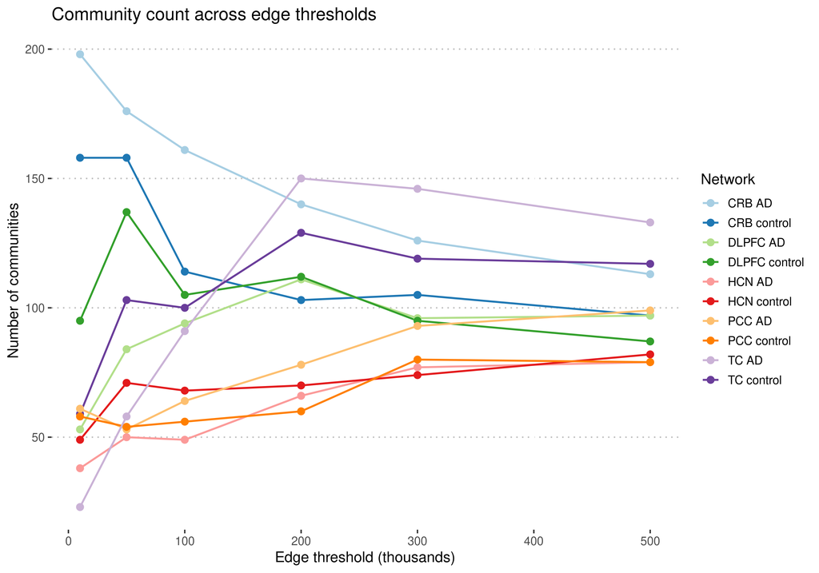

## 2.10 Max k-core

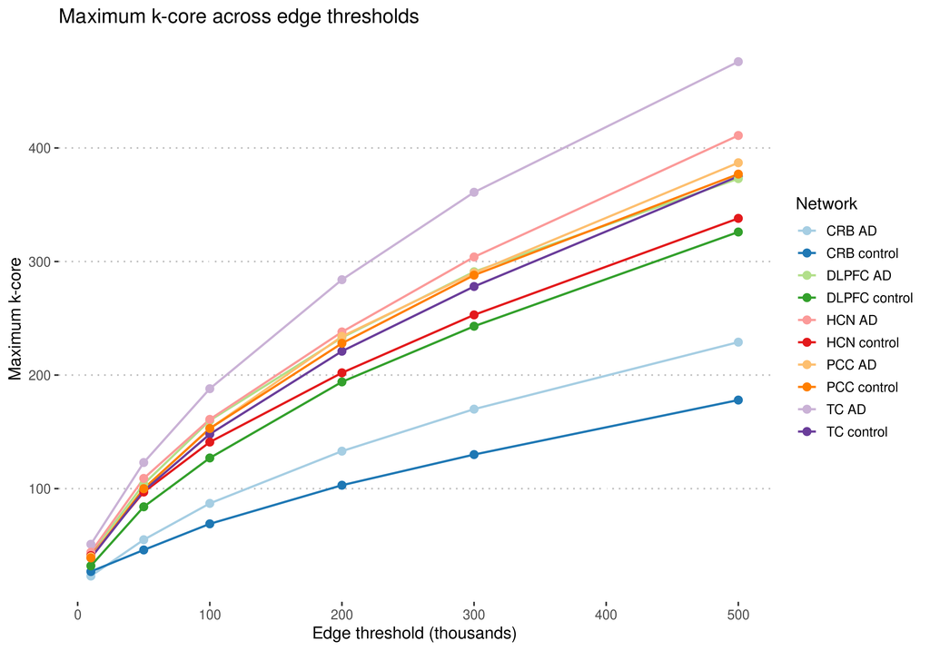

# 3. Key robustness tests

## 3.1 Regional clustering hierarchy stability (PCA)

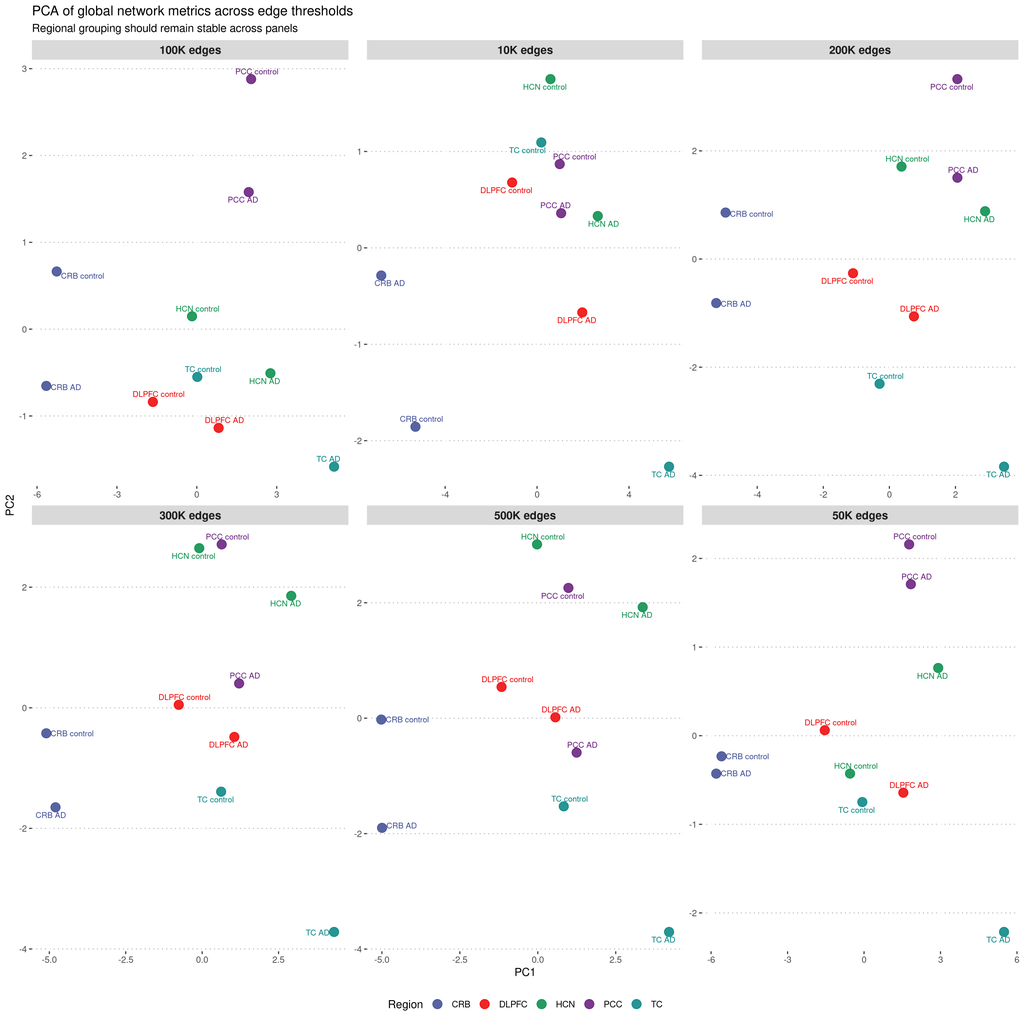

## 3.2 AD vs Control difference heatmap stability

For each threshold, we compute the signed log-transformed Z-score of AD minus control metric means per region. Consistent colour patterns across thresholds confirm robustness of the contraction-densification finding.

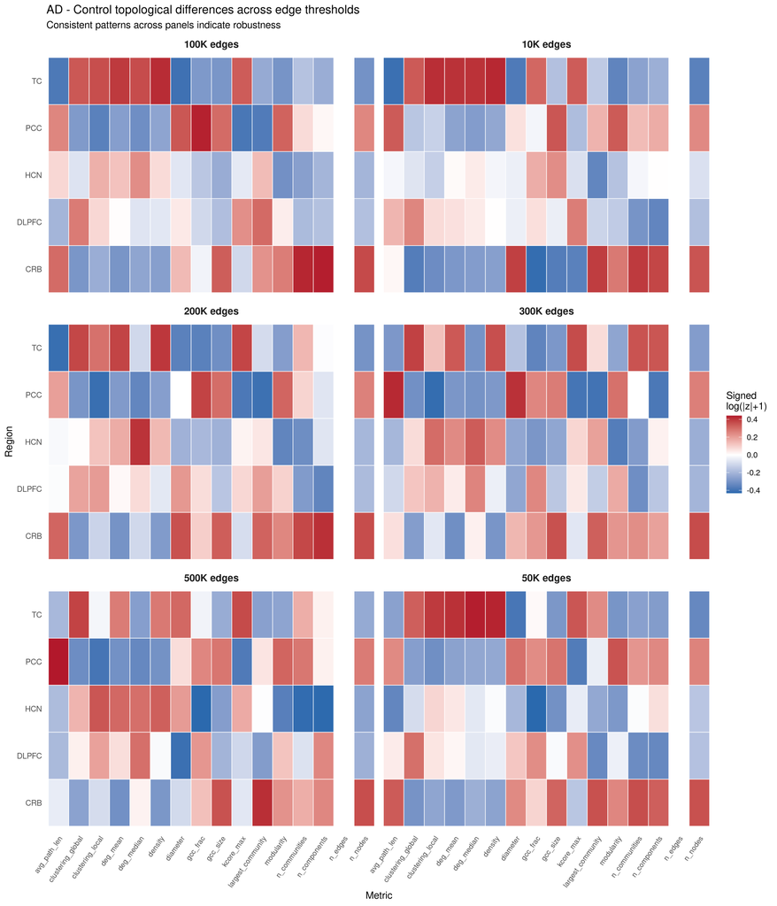

## 3.3 Rank correlation of metrics across thresholds

For each metric, we rank all 10 networks at each threshold, then compute the Spearman correlation of that ranking against the ranking at the reference threshold (200K). If $\rho > 0.9$ across all thresholds, the relative ordering of networks is preserved and the 200K cutoff is not driving the results.

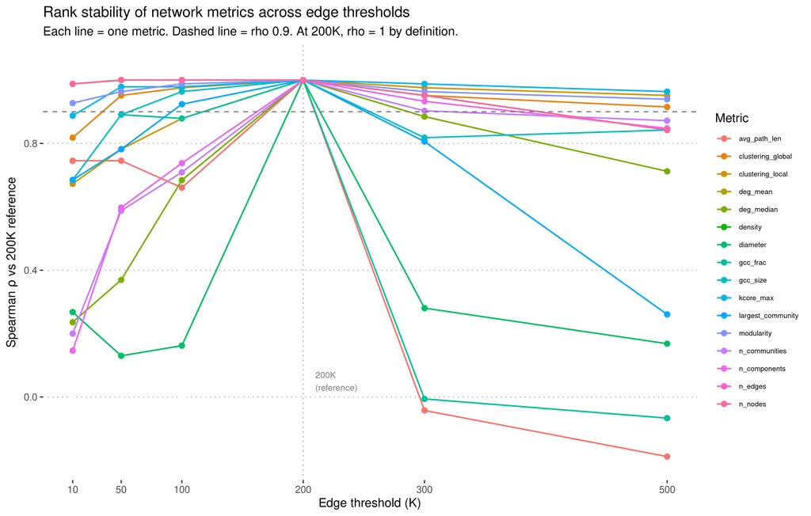

# 4. Degree distributions

## 4.1 Log-log degree distributions per network

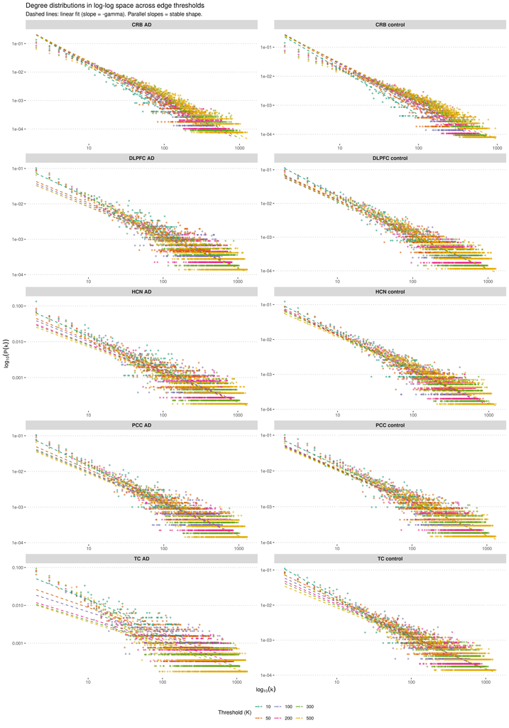

## 4.2 Gamma exponent across thresholds

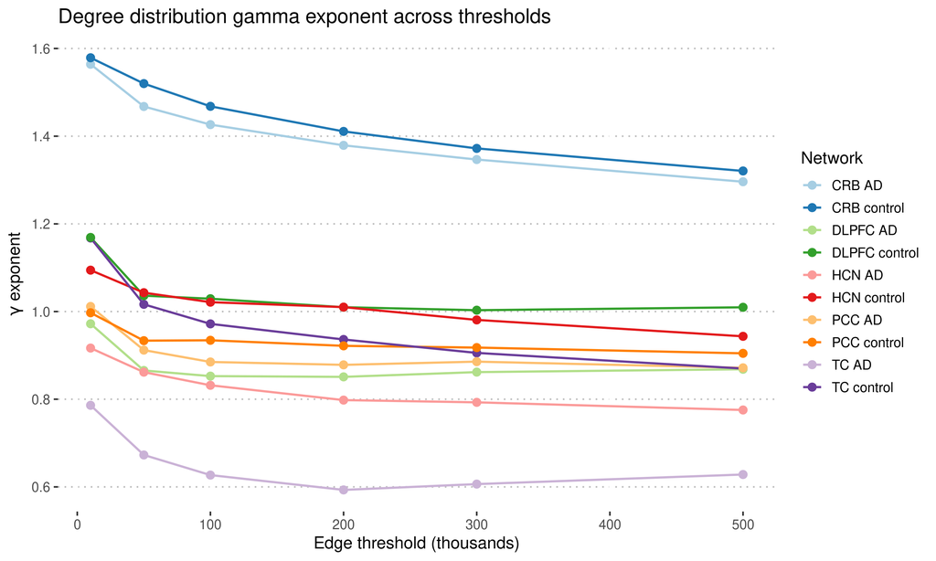

## 4.3 Summary tables

Degree distribution: gamma exponent and best-fit model across thresholds

| network | region | phenotype | threshold_k | gamma | best_fit |
| --- | --- | --- | --- | --- | --- |
| Mayo_CRB_counts_AD | CRB | AD | 10 | 1.564 | Gaussian |
| Mayo_CRB_counts_AD | CRB | AD | 50 | 1.468 | Gaussian |
| Mayo_CRB_counts_AD | CRB | AD | 100 | 1.426 | Gaussian |
| Mayo_CRB_counts_AD | CRB | AD | 200 | 1.379 | Gaussian |
| Mayo_CRB_counts_AD | CRB | AD | 300 | 1.347 | Gaussian |
| Mayo_CRB_counts_AD | CRB | AD | 500 | 1.296 | Gaussian |
| Mayo_CRB_counts_control | CRB | control | 10 | 1.579 | Gaussian |
| Mayo_CRB_counts_control | CRB | control | 50 | 1.520 | Gaussian |
| Mayo_CRB_counts_control | CRB | control | 100 | 1.468 | Gaussian |
| Mayo_CRB_counts_control | CRB | control | 200 | 1.411 | Gaussian |
| Mayo_CRB_counts_control | CRB | control | 300 | 1.372 | Gaussian |
| Mayo_CRB_counts_control | CRB | control | 500 | 1.321 | Gaussian |
| ROSMAP_DLPFC_counts_AD | DLPFC | AD | 10 | 0.972 | Gaussian |
| ROSMAP_DLPFC_counts_AD | DLPFC | AD | 50 | 0.866 | Gaussian |
| ROSMAP_DLPFC_counts_AD | DLPFC | AD | 100 | 0.853 | Gaussian |
| ROSMAP_DLPFC_counts_AD | DLPFC | AD | 200 | 0.851 | Gaussian |
| ROSMAP_DLPFC_counts_AD | DLPFC | AD | 300 | 0.862 | Gaussian |
| ROSMAP_DLPFC_counts_AD | DLPFC | AD | 500 | 0.868 | Gaussian |
| ROSMAP_DLPFC_counts_control | DLPFC | control | 10 | 1.169 | Gaussian |
| ROSMAP_DLPFC_counts_control | DLPFC | control | 50 | 1.036 | Gaussian |
| ROSMAP_DLPFC_counts_control | DLPFC | control | 100 | 1.029 | Gaussian |
| ROSMAP_DLPFC_counts_control | DLPFC | control | 200 | 1.010 | Gaussian |
| ROSMAP_DLPFC_counts_control | DLPFC | control | 300 | 1.003 | Gaussian |
| ROSMAP_DLPFC_counts_control | DLPFC | control | 500 | 1.010 | Gaussian |
| ROSMAP_HCN_counts_AD | HCN | AD | 10 | 0.917 | Exponential |
| ROSMAP_HCN_counts_AD | HCN | AD | 50 | 0.862 | Gaussian |
| ROSMAP_HCN_counts_AD | HCN | AD | 100 | 0.832 | Gaussian |
| ROSMAP_HCN_counts_AD | HCN | AD | 200 | 0.798 | Gaussian |
| ROSMAP_HCN_counts_AD | HCN | AD | 300 | 0.793 | Gaussian |
| ROSMAP_HCN_counts_AD | HCN | AD | 500 | 0.775 | Gaussian |
| ROSMAP_HCN_counts_control | HCN | control | 10 | 1.094 | Gaussian |
| ROSMAP_HCN_counts_control | HCN | control | 50 | 1.043 | Gaussian |
| ROSMAP_HCN_counts_control | HCN | control | 100 | 1.021 | Gaussian |
| ROSMAP_HCN_counts_control | HCN | control | 200 | 1.010 | Gaussian |
| ROSMAP_HCN_counts_control | HCN | control | 300 | 0.981 | Gaussian |
| ROSMAP_HCN_counts_control | HCN | control | 500 | 0.943 | Gaussian |
| ROSMAP_PCC_counts_AD | PCC | AD | 10 | 1.012 | Gaussian |
| ROSMAP_PCC_counts_AD | PCC | AD | 50 | 0.912 | Gaussian |
| ROSMAP_PCC_counts_AD | PCC | AD | 100 | 0.885 | Gaussian |
| ROSMAP_PCC_counts_AD | PCC | AD | 200 | 0.878 | Gaussian |
| ROSMAP_PCC_counts_AD | PCC | AD | 300 | 0.886 | Gaussian |
| ROSMAP_PCC_counts_AD | PCC | AD | 500 | 0.872 | Gaussian |
| ROSMAP_PCC_counts_control | PCC | control | 10 | 0.997 | Gaussian |
| ROSMAP_PCC_counts_control | PCC | control | 50 | 0.934 | Gaussian |
| ROSMAP_PCC_counts_control | PCC | control | 100 | 0.934 | Gaussian |
| ROSMAP_PCC_counts_control | PCC | control | 200 | 0.922 | Gaussian |
| ROSMAP_PCC_counts_control | PCC | control | 300 | 0.918 | Gaussian |
| ROSMAP_PCC_counts_control | PCC | control | 500 | 0.905 | Gaussian |
| Mayo_TC_counts_AD | TC | AD | 10 | 0.786 | Gaussian |
| Mayo_TC_counts_AD | TC | AD | 50 | 0.673 | Gaussian |
| Mayo_TC_counts_AD | TC | AD | 100 | 0.627 | Gaussian |
| Mayo_TC_counts_AD | TC | AD | 200 | 0.593 | Gaussian |
| Mayo_TC_counts_AD | TC | AD | 300 | 0.606 | Gaussian |
| Mayo_TC_counts_AD | TC | AD | 500 | 0.628 | Gaussian |
| Mayo_TC_counts_control | TC | control | 10 | 1.168 | Gaussian |
| Mayo_TC_counts_control | TC | control | 50 | 1.016 | Gaussian |
| Mayo_TC_counts_control | TC | control | 100 | 0.972 | Gaussian |
| Mayo_TC_counts_control | TC | control | 200 | 0.936 | Gaussian |
| Mayo_TC_counts_control | TC | control | 300 | 0.906 | Gaussian |
| Mayo_TC_counts_control | TC | control | 500 | 0.870 | Gaussian |

Best-fit degree distribution model per network across thresholds

| region | phenotype | thr_10 | thr_100 | thr_200 | thr_300 | thr_50 | thr_500 |
| --- | --- | --- | --- | --- | --- | --- | --- |
| CRB | AD | Gaussian | Gaussian | Gaussian | Gaussian | Gaussian | Gaussian |
| CRB | control | Gaussian | Gaussian | Gaussian | Gaussian | Gaussian | Gaussian |
| DLPFC | AD | Gaussian | Gaussian | Gaussian | Gaussian | Gaussian | Gaussian |
| DLPFC | control | Gaussian | Gaussian | Gaussian | Gaussian | Gaussian | Gaussian |
| HCN | AD | Exponential | Gaussian | Gaussian | Gaussian | Gaussian | Gaussian |
| HCN | control | Gaussian | Gaussian | Gaussian | Gaussian | Gaussian | Gaussian |
| PCC | AD | Gaussian | Gaussian | Gaussian | Gaussian | Gaussian | Gaussian |
| PCC | control | Gaussian | Gaussian | Gaussian | Gaussian | Gaussian | Gaussian |
| TC | AD | Gaussian | Gaussian | Gaussian | Gaussian | Gaussian | Gaussian |
| TC | control | Gaussian | Gaussian | Gaussian | Gaussian | Gaussian | Gaussian |

# 5. Interpretation guide

**What each section answers for the reviewer:**

1. **Section 2 (line plots):** If lines run roughly parallel without crossing, the relative differences between networks are preserved regardless of the edge threshold. Vertical spread at each threshold shows the magnitude of inter-network differences; what matters is that the *ordering* is stable.
2. **Section 3.1 (PCA facets):** If regional clusters (same colour) stay together across panels, the finding that networks group by region rather than disease status is robust.
3. **Section 3.2 (heatmaps):** If the colour pattern (which regions show increases vs decreases in which metrics) is consistent across panels, the contraction-densification pattern and CRB expansion pattern are not artifacts.
4. **Section 3.3 (rank correlations):** Spearman rho = 1 at 200K by definition (reference). If rho stays above 0.9 at other thresholds, the 200K cutoff produces the same relative ordering as any other cutoff. Metrics that drop below 0.9 at extreme thresholds (10K) identify the least robust topological features.
5. **Section 4 (degree distributions):** If all networks are Gaussian at all thresholds, it means the degree distributions are unimodal and symmetric rather than heavy-tailed. This is expected for pruned MI networks because retaining only the top-N edges compresses the upper tail of the degree distribution — the pruning itself imposes a ceiling on maximum degree. The key question is whether the *gamma exponent* is stable, not whether the best-fit model changes.